# פרוייקט מס' 29: משלחות טיפוס להרי ההימלאיה

### Project team members:

- עדי הורן
- תמר קאהן

### Project description:

בפרוייקט ננתח נתונים על יותר מ-11,000 משלחות טיפוס בהימלאיה, משנת 1905 ועד 2024.הנתונים מתרכזים במסלולי טיפוס, מטפסים, שימוש בחמצן, הצלחות וכשלונות, תאונות, נותני חסות, מדינות ועוד. ננסה לנתח מגמות היסטוריות, להבין סיכונים, אלו מדינות שלחו משלחות ולחקור מה גורם למשלחת להצליח או להיכשל?

### Link to the data:

https://www.kaggle.com/datasets/siddharth0935/himalayan-expeditions

### Explain the data source:

דאטה מגיעה מאתר Kaggle. הנתונים נאספו מתוך ארכיוני משלחות, ספרים, יומני טיפוס ותקשורת עם מטפסים

#### Read you file from Github:

"https://raw.githubusercontent.com/tamar1k/project_EDA/refs/heads/main/exped.csv"

את העבודה עשינו ביחד עם קשיים רבים מצד המילואים. תמר חזרה מחודשיים של מילואים ואת עדי הקפיצו בצו 8. אז ניסינו להפגש ופחות עבד אז כל אחת עבדה בזמנה וביכולה ושלחנו מיד לשניה. כך יצא לדוגמא- שאת הגרפים של השאלה על השנים תמר עשתה ועדי ניתחה וסיכמה את התובנות, ובשאלה על העונות להפך. כך כל אחת התנסתה בהכל ועבדנו בשיתוף פעולה..

#### Describe the data

- How many rows?
- How many columns?
- How many numeric columns? (not including numerical identifiers - numbers that uniquely define the row)
- How many categorical columns? (not including string identifiers - values that uniquely define the row)

```python
import pandas as pd
import numpy as np
import seaborn as sns
import matplotlib.pyplot as plt
```

```python
him_df = pd.read_csv(r"https://raw.githubusercontent.com/tamar1k/project_EDA/refs/heads/main/exped.csv", low_memory=False)
him_df
```

|  | expid | peakid | year | season | host | route1 | route2 | route3 | route4 | nation | ... | accidents | achievment | agency | comrte | stdrte | primrte | primmem | primref | primid | chksum |
| --- | --- | --- | --- | --- | --- | --- | --- | --- | --- | --- | --- | --- | --- | --- | --- | --- | --- | --- | --- | --- | --- |
| 0 | ANN260101 | ANN2 | 1960 | Spring | Nepal | NW Ridge-W Ridge | NaN | NaN | NaN | UK | ... | NaN | NaN | NaN | False | False | False | False | False | NaN | 2442047 |
| 1 | ANN269301 | ANN2 | 1969 | Autumn | Nepal | NW Ridge-W Ridge | NaN | NaN | NaN | Yugoslavia | ... | Draslar frostbitten hands and feet | NaN | NaN | False | False | False | False | False | NaN | 2445501 |
| 2 | ANN273101 | ANN2 | 1973 | Spring | Nepal | W Ridge-N Face | NaN | NaN | NaN | Japan | ... | NaN | NaN | NaN | False | False | False | False | False | NaN | 2446797 |
| 3 | ANN278301 | ANN2 | 1978 | Autumn | Nepal | N Face-W Ridge | NaN | NaN | NaN | UK | ... | NaN | NaN | NaN | False | False | False | False | False | NaN | 2448822 |
| 4 | ANN279301 | ANN2 | 1979 | Autumn | Nepal | N Face-W Ridge | NW Ridge of A-IV | NaN | NaN | UK | ... | NaN | NaN | NaN | False | False | False | False | False | NaN | 2449204 |
| ... | ... | ... | ... | ... | ... | ... | ... | ... | ... | ... | ... | ... | ... | ... | ... | ... | ... | ... | ... | ... | ... |
| 11420 | PATR24201 | PATR | 2024 | Summer | Nepal | NW Ridge | NaN | NaN | NaN | Nepal | ... | NaN | NaN | NaN | False | False | False | False | False | NaN | 2463218 |
| 11421 | PUMO24101 | PUMO | 2024 | Spring | Nepal | SE Face | NaN | NaN | NaN | Romania | ... | NaN | NaN | Asian Trekking | False | False | False | False | False | NaN | 2789 |
| 11422 | PUTH24101 | PUTH | 2024 | Spring | Nepal | NE Face | NaN | NaN | NaN | S Africa | ... | NaN | NaN | Holiday Himalaya Treks | False | False | False | False | False | NaN | 2463320 |
| 11423 | TKPO24101 | TKPO | 2024 | Spring | Nepal | NE Face | NaN | NaN | NaN | USA | ... | NaN | NaN | iTrek Nepal | False | False | False | False | False | NaN | 2463393 |
| 11424 | YLNG24101 | YLNG | 2024 | Spring | Nepal | SE Rib | NaN | NaN | NaN | Slovakia | ... | NaN | NaN | Cho Oyu Trekking | False | False | False | False | False | NaN | 2463459 |

11425 rows × 65 columns

```python
him_df.describe()
```

|  | year | smttime | smtdays | totdays | highpoint | camps | rope | totmembers | smtmembers | mdeaths | tothired | smthired | hdeaths | chksum |
| --- | --- | --- | --- | --- | --- | --- | --- | --- | --- | --- | --- | --- | --- | --- |
| count | 11425.000000 | 4982.00000 | 9671.000000 | 8406.000000 | 11425.000000 | 11425.000000 | 11425.000000 | 11425.000000 | 11425.000000 | 11425.000000 | 11425.000000 | 11425.000000 | 11425.000000 | 1.142500e+04 |
| mean | 2003.120700 | 1073.73605 | 21.488781 | 26.337378 | 7093.530328 | 2.255142 | 172.681225 | 6.123063 | 2.018556 | 0.072035 | 3.157899 | 1.244464 | 0.029322 | 2.295333e+06 |
| std | 15.235501 | 395.92010 | 14.896473 | 15.506469 | 1814.995214 | 1.573960 | 671.047934 | 5.563227 | 3.126758 | 0.366884 | 5.630387 | 2.979685 | 0.275197 | 6.434430e+05 |
| min | 1905.000000 | 14.00000 | 0.000000 | 0.000000 | 0.000000 | 0.000000 | 0.000000 | 0.000000 | 0.000000 | 0.000000 | 0.000000 | 0.000000 | 0.000000 | 2.015000e+03 |
| 25% | 1996.000000 | 829.25000 | 10.000000 | 14.000000 | 6550.000000 | 1.000000 | 0.000000 | 2.000000 | 0.000000 | 0.000000 | 0.000000 | 0.000000 | 0.000000 | 2.452821e+06 |
| 50% | 2007.000000 | 1045.00000 | 19.000000 | 24.000000 | 7200.000000 | 2.000000 | 0.000000 | 5.000000 | 1.000000 | 0.000000 | 2.000000 | 0.000000 | 0.000000 | 2.458388e+06 |
| 75% | 2014.000000 | 1300.00000 | 31.000000 | 37.000000 | 8188.000000 | 3.000000 | 0.000000 | 8.000000 | 3.000000 | 0.000000 | 4.000000 | 1.000000 | 0.000000 | 2.461008e+06 |
| max | 2024.000000 | 8040.00000 | 388.000000 | 280.000000 | 8850.000000 | 34.000000 | 8700.000000 | 99.000000 | 39.000000 | 10.000000 | 99.000000 | 48.000000 | 11.000000 | 2.334512e+07 |

```python
row_col_df = him_df.shape
rows = print('מספר השורות:' ,row_col_df[0])
columns = print('מספר העמודות:' ,row_col_df[1])
```

```
מספר השורות: 11425
מספר העמודות: 65
```

```python
numeric_cols = him_df.select_dtypes(include=['number'])
identifier_cols = ["id", "expedition_id"]
numeric_cols = numeric_cols.drop(columns=identifier_cols, errors='ignore')
print(f"מספר העמודות המספריות: (excluding identifiers): {numeric_cols.shape[1]}")
```

```
מספר העמודות המספריות: (excluding identifiers): 14
```

```python
categorical_cols = him_df.select_dtypes(include=['object'])
identifier_cols = ["expedition_name", "climber_name"]
categorical_cols = categorical_cols.drop(columns=identifier_cols, errors='ignore')
print(f"מספר העמודות הקטגוריות: {categorical_cols.shape[1]}")
```

```
מספר העמודות הקטגוריות: 28
```

```python
him_df.info()
```

```
<class 'pandas.core.frame.DataFrame'>
RangeIndex: 11425 entries, 0 to 11424
Data columns (total 65 columns):
 #   Column      Non-Null Count  Dtype
---  ------      --------------  -----
 0   expid       11425 non-null  object
 1   peakid      11425 non-null  object
 2   year        11425 non-null  int64
 3   season      11425 non-null  object
 4   host        11425 non-null  object
 5   route1      11275 non-null  object
 6   route2      360 non-null    object
 7   route3      30 non-null     object
 8   route4      5 non-null      object
 9   nation      11425 non-null  object
```

[output cut: 57 more lines]

#### Write three questions you would like to answer using this data

1. מה השפיע על כמות המשלחות בהמלך השנים?
2. אלו מדינות מהם יוצאים לטיפוס על ההר והאם ואיך זה משפיע על המשלחת?
3. מתי יוצאים למסע, ומהי השפעת העונה וחודשי השנה על ההצלחה בטיפוס

## data cleaning

```python
him_df['season'].value_counts()
```

```
season
Autumn     5634
Spring     5334
Winter      340
Summer      115
Unknown       2
Name: count, dtype: int64
```

```python
him_df = him_df[him_df['season']!='Unknown']
```

```python
him_df['success1'].value_counts(dropna=False)
```

```
success1
True     6276
False    5147
Name: count, dtype: int64
```

### Observation 1:

בתצפית הראשונה רצינו לראות איך השתנו מספר המשלחות להרי ההימלאיה לאורך השנים , במטרה להבין האם התחום נהיה פופולרי יותר עם הזמן, והאם יש שנים יוצאות דופן שבהן קרה משהו מעניין – כמו ירידה חדה או קפיצה חדה

```
<function matplotlib.pyplot.show(close=None, block=None)>
```

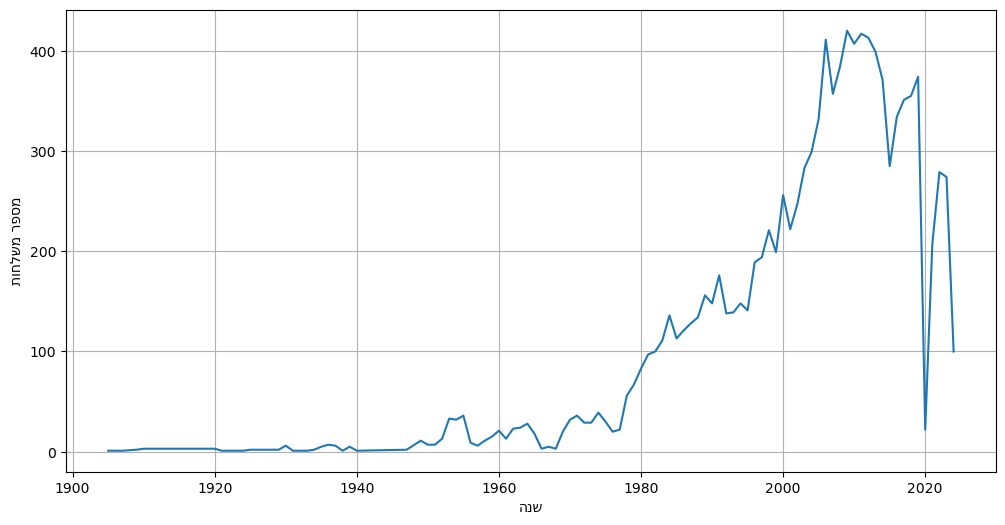

```python
him_df = him_df.copy()
him_df["success_total"] = him_df[["success1", "success2", "success3", "success4"]].sum(axis=1)
yaer_counts = him_df['year'].value_counts()
him_df['year'] = pd.to_numeric(him_df['year'], errors='coerce')



yaer_counts = yaer_counts.sort_index()
plt.figure(figsize = (12, 6))
plt.plot(yaer_counts.index, yaer_counts.values)
plt.xlabel('הנש')
plt.ylabel(r"תוחלשמ רפסמ")
plt.grid(True)
plt.show
```

בגרף זה אנו רואים את כמות המשלחות של טיפוס להימלאיה בפילוח של שנים. ניתן לראות התחלה קטנה בשנות ה־50, עם עלייה הדרגתית בעשורים הבאים. אנו חושבות שעלייה זו נובעת בשל סיום מלחמת העולם השנייה שהרי רואים שקצת לפני המלחמה הייתה עלייה קטנה וירידה בעקבות המלחמה. כמו כן , העלייה המתועדת הראשונה על האוורסט שזהו המקום הגבוה ביותר בהימלאיה קרתה במהלך שנות החמישים. בנוסף , החל משנות ה־90 ניכר שינוי חד, כאשר התחום חווה "פריצת דרך גלובלית" – משלחות מכל רחבי העולם ושיאים שנתיים במספר המשתתפים.. עם זאת, ניתן לזהות ירידות חדות בשנים מסוימות – במיוחד ב־2015 , שנה שבה הייתה רעידת אדמה בנפאל שגבתה את חייהם של 20 מטיילים ו80 מטיילים נפצעו במהלך הטיפוס להילמלאיה וב־2020 שנה שבה הייתה מגפת הקורונה . שנים אלו ממחישות עד כמה המשלחות של טיפוס להימלאיה רגישות לאירועים גלובליים ואזוריים.

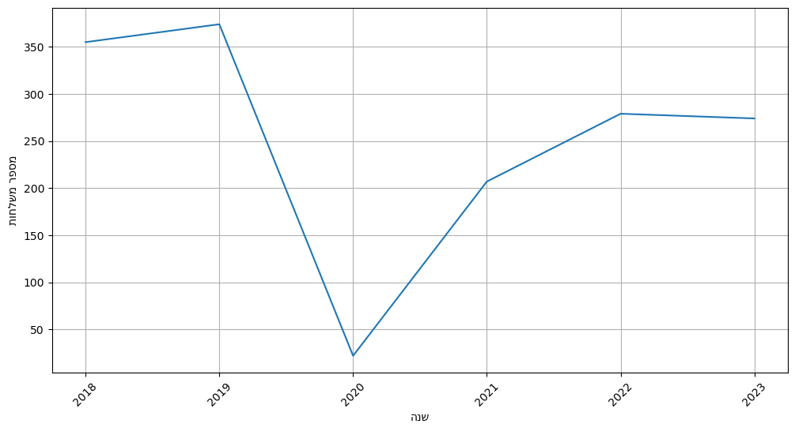

```python
filtered_df = him_df[(him_df['year'] >= 2018) & (him_df['year'] <= 2023)]
year_counts_filtered = filtered_df['year'].value_counts().sort_index()

plt.figure(figsize=(12, 6))
plt.plot(year_counts_filtered.index, year_counts_filtered.values)
plt.xlabel('הנש')
plt.ylabel(r"תוחלשמ רפסמ")
plt.xticks(rotation=45)
plt.grid(True)
plt.show()
```

בבגרף הנ"ל אנו רואים את כמות המשלחות בין השנים 2018-2023 . אנו רואים את הירידה החדה בשנת 2020 במספר המשלחות בעקבות מגפת הקורונה שהובילה לסגירת גבולות וביטול משלחות רבות.

```python
expeditions_2020 =  him_df[ him_df['year'] == 2020]['nation'].unique()
print(expeditions_2020)
expeditions_2020_counts =  him_df[ him_df['year'] == 2020]['nation'].value_counts()
print(expeditions_2020_counts)
season_counts =  him_df[ him_df['year'] == 2020]['season'].value_counts()
print(season_counts)
```

```
['China' 'Nepal' 'USA' 'UK' 'Italy' 'Belgium' 'India' 'Romania'
 'Switzerland' 'Bahrain']
nation
Nepal          7
China          4
USA            2
UK             2
Italy          2
Belgium        1
India          1
Romania        1
Switzerland    1
Bahrain        1
Name: count, dtype: int64
season
Autumn    13
Winter     6
Spring     3
Name: count, dtype: int64
```

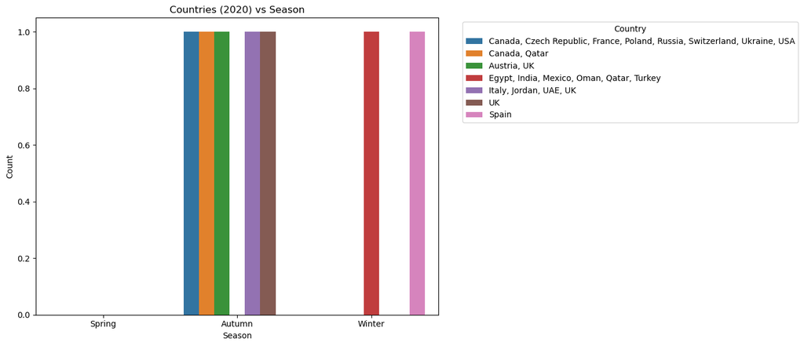

```python
df_2020 = him_df[him_df['year'] == 2020].copy()

if df_2020['countries'].apply(lambda x: isinstance(x, str)).all():
    df_2020['countries'] = df_2020['countries'].str.split(',')
    df_2020 = df_2020.explode('countries')
    df_2020['countries'] = df_2020['countries'].str.strip()

plt.figure(figsize=(14, 6))
sns.countplot(data=df_2020, x='season', hue='countries', palette='tab10')
plt.title('Countries (2020) vs Season')
plt.xlabel('Season')
plt.ylabel('Count')
plt.legend(title='Country', bbox_to_anchor=(1.05, 1), loc='upper left')
plt.tight_layout()
plt.show()
```

בגרף הנ"ל אנו רואים את הפילוח של המשלחות טיפוס לעונות השנה בשנת 2020. אנו רואים שרוב המשלחות הם לקראת סוף שנת 2020 כי בתחילת השנה השמיים היו סגורים והיה קשה להגיע לאזור ממדינות אחרות .

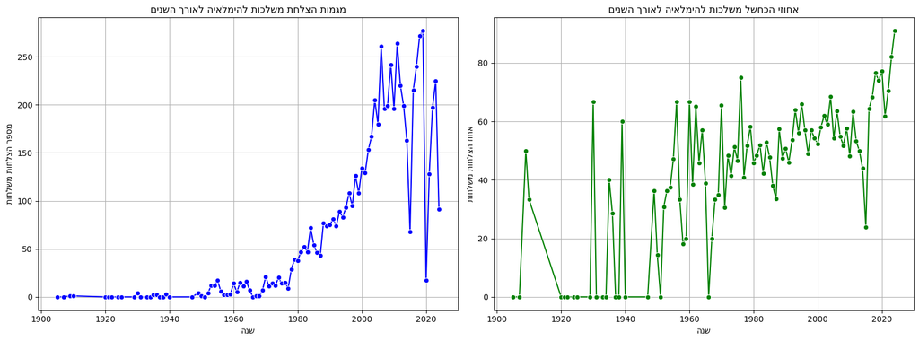

```python
import pandas as pd

# חישוב מספר ההצלחות הכולל לכל שנה
him_df["success_total"] = him_df[["success1", "success2", "success3", "success4"]].sum(axis=1)
success_by_year = him_df.groupby("year")["success_total"].sum().reset_index()

# חישוב מספר המשלחות הכולל לכל שנה
total_expeditions_by_year = him_df.groupby("year")["expid"].count().reset_index()

# שילוב הנתונים בטבלה אחת
success_by_year = success_by_year.merge(total_expeditions_by_year, on="year")

# חישוב אחוז ההצלחה
success_by_year["success_rate"] = (success_by_year["success_total"] / success_by_year["expid"]) * 100
fig, axes = plt.subplots(1, 2, figsize=(16, 6))

sns.lineplot(data=success_by_year, x="year", y="success_total", marker="o", color="b", ax=axes[0])
axes[0].set_xlabel('הנש')
axes[0].set_ylabel("תוחלשמ תוחלצה רפסמ")
axes[0].set_title("םינשה ךרואל היאלמיהל תוכלשמ תחלצה תומגמ")
axes[0].grid(True)

sns.lineplot(data=success_by_year, x="year", y="success_rate", marker="o", color="g", ax=axes[1])
axes[1].set_xlabel('הנש')
axes[1].set_ylabel("תוחלשמ תוחלצה זוחא")
axes[1].set_title("םינשה ךרואל היאלמיהל תוכלשמ לשחכה יזוחא")
axes[1].grid(True)

plt.tight_layout()
plt.show()
```

```python
expeditions_2020 =  him_df[ him_df['year'] == 2020]['nation'].unique()
print(expeditions_2020)
expeditions_2020_counts =  him_df[ him_df['year'] == 2020]['nation'].value_counts()
print(expeditions_2020_counts)
season_counts =  him_df[ him_df['year'] == 2020]['season'].value_counts()
print(season_counts)
```

```
['China' 'Nepal' 'USA' 'UK' 'Italy' 'Belgium' 'India' 'Romania'
 'Switzerland' 'Bahrain']
nation
Nepal          7
China          4
USA            2
UK             2
Italy          2
Belgium        1
India          1
Romania        1
Switzerland    1
Bahrain        1
Name: count, dtype: int64
season
Autumn    13
Winter     6
Spring     3
Name: count, dtype: int64
```

בגרף הנל אנו מנסים לחשב את אחוזי ההצלחה של המשלחות ביחס לכמות המשלחות שיצאה בשנה (הרי כמובן שלפני שנות החמישים של המאה ה19, כאשר יצאו משלחות בודדות כל שנה, כמות המשלחות שהצליחו לא משתווה לאחוזי ההצלחה) אנו בעצם רוצות לבדוק האם המהפכה הטכנולוגית, העולם שהתקדם גרמו שיותר משלחות הצליחו להגיע לפסגת ההימלאיה .  
ניתן לראות כי הגרפים מראים שמספר המשלחות המצליחות להימלאיה נמצא במגמת עלייה לאורך השנים, עם שיאים בשנים האחרונות (למעט שנים חריגות). אחוזי ההצלחה עצמם משתפרים, מה שמעיד על שיפור בתכנון, ניסיון נצבר בקרב סוכניות ומטפסים, ותנאים לוגיסטיים כמו ביגוד , חמצן ועוד. ניסיון נצבר בקרב מטפסים וסוכנויות

### Observation 2:

בתצפית השניה רצינו לבחון המשלחות להרי ההימלאיה בפילוח למדינות, במטרה להבין את סוג מדינות מהן יוצאים משלחות, ואת ההשפעה אם ישנה על הצלחת המסע

```
nation
Myanmar            1
Tunisia            1
Saudi Arabia       1
UK/USA             1
Cyprus             1
Germany/Iran       1
Guatemala          1
Albania            1
Sri Lanka          1
Nepal/Australia    1
Jordan             1
Bhutan             1
Armenia            1
Liechtenstein      1
Hong Kong          1
Afghanistan        1
Name: count, dtype: int64 1
nation
USA    1286
Name: count, dtype: int64 1286
```

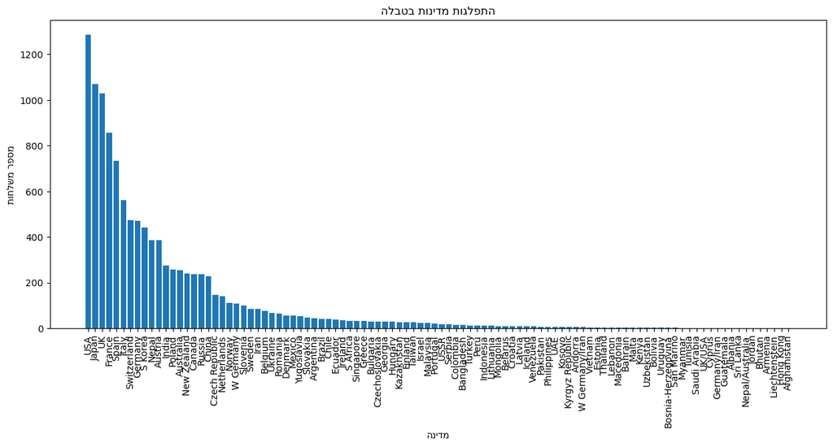

```python
nation_counts = him_df['nation'].value_counts()
nation_min = nation_counts.min()
print(nation_counts[nation_counts == nation_min], nation_min)
nation_max = nation_counts.max()
print(nation_counts[nation_counts == nation_max], nation_max)
nation_mode = nation_counts.mode()


nation_cmode = pd.Series(nation_mode).value_counts()

plt.figure(figsize = (15 ,6))
plt.bar(nation_counts.index, nation_counts.values)
plt.xlabel("הנידמ")
plt.ylabel("תוחלשמ רפסמ")
plt.title("הלבטב תונידמ תוגלפתה")

plt.xticks(rotation=90)

plt.show()
```

עכשיו נבוא לבחון את הצלחת המשלחות ביחס למדינות אשר הוציאו את המשלחות, נבחון האם יש משמעות למדינה השולחת מבחינת אמצעים, אימונים ותמיכה לוגיסטית. נזכיר שראינו שמדינות מערביות מלכתחילה שולחות יותר משלחות

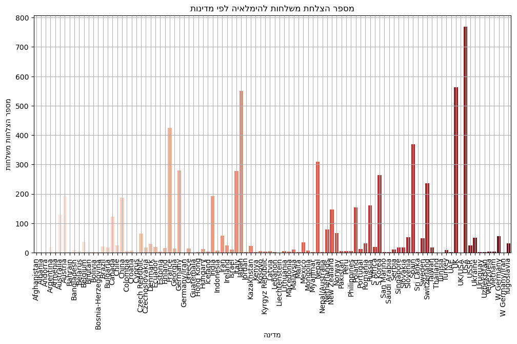

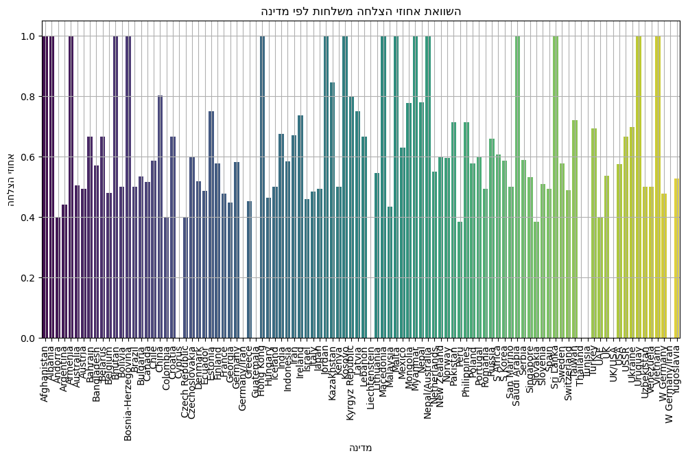

```python
him_df["success_total"] = him_df[["success1", "success2", "success3", "success4"]].sum(axis=1)
success_by_country = him_df.groupby("nation")["success_total"].sum().reset_index()
total_expeditions_by_country = him_df.groupby("nation")["expid"].count().reset_index()
success_by_country = success_by_country.merge(total_expeditions_by_country, on="nation")
success_by_country["success_rate"] = (success_by_country["success_total"] / success_by_country["expid"]) * 100

plt.figure(figsize=(12, 6))
sns.barplot(data=success_by_country, x="nation", y="success_total", hue="nation", palette="Reds", legend=False)
plt.xlabel("הנידמ")
plt.ylabel("תוחלשמ תוחלצה רפסמ")
plt.title("תונידמ יפל היאלמיהל תוחלשמ תחלצה רפסמ")
plt.xticks(rotation=90)
plt.grid(True)
plt.show()


success_by_country = him_df.groupby("nation")["success1"].mean().reset_index()


plt.figure(figsize=(12, 6))
sns.barplot(data=success_by_country, x="nation", y="success1",hue="nation", palette="viridis",legend=False)
plt.xlabel("הנידמ")
plt.ylabel("החלצה יזוחא")
plt.title("הנידמ יפל תוחלשמ החלצה יזוחא תאוושה")
plt.xticks(rotation=90)
plt.grid(True)
plt.show()
```

### Observation 3:

בתצפית השלישית החלטנו להתמקד ביציאת המשלחות למסע בפילוח לעונות וחודשי השנה ואת ההשפעה של עונות השנה על המסע

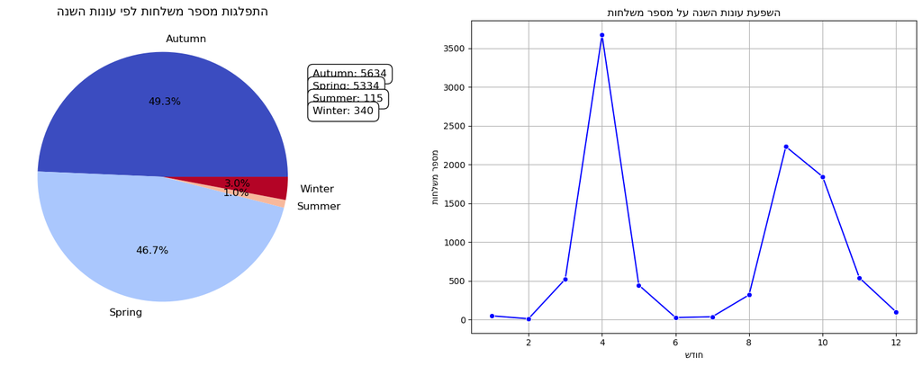

```python
# חישוב מספר המשלחות לכל עונה
season_counts = him_df.groupby("season")["expid"].count().reset_index()

# יצירת נתונים לגרף עוגה
season_labels = season_counts["season"]
expeditions_values = season_counts["expid"]

# המרת תאריך בסיס המחנה לעמודת חודש ושנה
him_df["bcdate"] = pd.to_datetime(him_df["bcdate"])
him_df["month"] = him_df["bcdate"].dt.month
him_df["year"] = him_df["bcdate"].dt.year

# חישוב מספר משלחות לפי חודש
expeditions_by_month = him_df.groupby("month")["expid"].count().reset_index()

# יצירת שני גרפים זה לצד זה
fig, axes = plt.subplots(1, 2, figsize=(16, 6))

# 🔹 גרף עוגה - התפלגות מספר המשלחות לפי עונה
wedges, texts, autotexts = axes[0].pie(expeditions_values, labels=season_labels, autopct="%1.1f%%",
                                       colors=plt.cm.coolwarm(np.linspace(0, 1, len(season_labels))),
                                       textprops={'fontsize': 12})

# הוספת מספרים במסגרת ליד הגרף העוגה
for i, text in enumerate(texts):
    axes[0].text(1.2, 0.8 - (i * 0.1), f"{season_labels[i]}: {expeditions_values[i]}",
                 fontsize=12, color="black", bbox=dict(facecolor="white", edgecolor="black", boxstyle="round,pad=0.5"))

axes[0].set_title("הנשה תונוע יפל תוחלשמ רפסמ תוגלפתה", fontsize=14)

# 🔹 גרף קווי - מספר משלחות לפי חודש
sns.lineplot(data=expeditions_by_month, x="month", y="expid", marker="o", color="b", ax=axes[1])
axes[1].set_xlabel("שדוח")
axes[1].set_ylabel("תוחלשמ רפסמ")
axes[1].set_title("תוחלשמ רפסמ לע הנשה תונוע תעפשה")
axes[1].grid(True)

plt.tight_layout()
plt.show()
```

בגרפים שלפנינו אנו מזהים כי רוב המשלחות יוצאות לדרכן בעונות מעבר- סתיו, אביב(96%). הבחנה שקיימת בין אביב לסתיו – בעוד שבאביב יציאת המשלחות מתרכזת בעיקר בחודש אפריל, הסתיו מאופיין בפיזור רחב יותר בין אוגוסט לנובמבר, כאשר השיא בספטמבר, מה שעשוי להסביר את מובילות הסתיו עם כמעט 50% מהמשלחות. אנו מזהים הבחנה גם בין החורף לקיץ שלמרות התנאים הקשים בגבהים, בחורף יצאו כמעט פי 3 יותר משלחות מאשר בקיץ. ייתכן שהטיפוס בקיץ מציב אתגרים ייחודיים המובילים להימנעות גבוהה יחסית בתקופה זו.

:ולאחר שראינו את פילוח המשלחות על בסיס עונות השנה נבחן את הצלחות וסיבות להפסקת המשלחות בפילוח לעונות

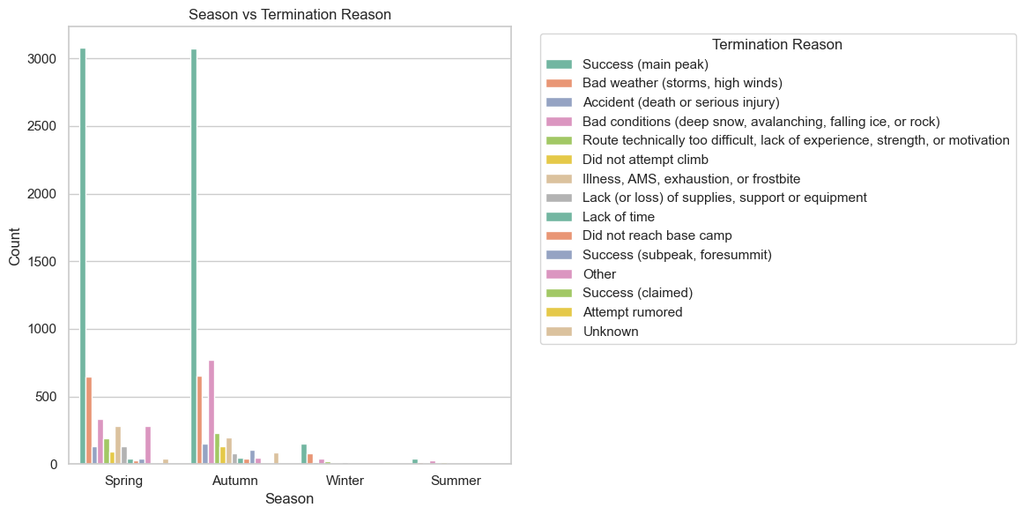

```python
# Make plots look better
sns.set(style="whitegrid")

# === 1. season vs termreason ===
plt.figure(figsize=(12, 6))
sns.countplot(data=him_df, x='season', hue='termreason', palette='Set2')
plt.title('Season vs Termination Reason')
plt.xlabel('Season')
plt.ylabel('Count')
plt.legend(title='Termination Reason', bbox_to_anchor=(1.05, 1), loc='upper left')
plt.tight_layout()
plt.show()
```

סיכום תובנות ממסעות הטיפוס

- בעונות המעבר (אביב וסתיו) נרשם מספר ההצלחות הגבוה ביותר בהגעה לפסגה, מה שמעיד שמזג האוויר בתקופות אלה מספק תנאים נוחים יותר לטיפוס. עם זאת, תנאי מזג האוויר עדיין מהווים גורם מרכזי להפסקת משלחות.
- למרות התנאים הקיצוניים בגבהים, מספר המשלחות שיוצאות ומגיעות ליעדן בחורף גבוה יחסית, מה שמעיד על התאמות ייחודיות לטיפוס בעונה זו.
- סכנות בקיץ – בקיץ לא נרשמו הפסקות משלחות בשל מזג אוויר גרוע, אלא בשל התופעות הנלוות למזג אוויר נעים יותר—הפשרת השלג והקרח שמובילה למפולות וסיכונים מוגברים.
- השפעת הקיץ על הסתיו – הסתיו, שמגיע לאחר הקיץ, מציג אחוז גבוה של הפסקות משלחות בשל תנאי שטח ומזג אוויר מאתגרים, ככל הנראה כתוצאה מהשינויים שהתרחשו בקיץ. בעקבות ההבנות על ההשפעות המסוכנות של הקיץ ומזג האוויר החם יחסית, מעניין אם זו הסיבה שבגינה יוצאים לדרך באביב כמעט אך באפריל לפני שיהיה חם מדי

### Summary

> Anything you'd like to say - your conclusions, summary, how hard you worked etc.

במהלך הפרויקט בחנו את מגמת המשלחות להרי ההימלאיה לאורך השנים, את השפעת העונה וחודשי השנה ואת המדינות שמוציאים את המשלחות התמקדות בפרמטרים כמו מספר המשלחות, אחוזי הצלחה, והשפעות חיצוניות (אירועים עולמיים, תנאים גיאופוליטיים ועוד). הנתונים נותחו באמצעות גרפים המציגים את מספר המשלחות לפי שנה, מספר ההצלחות, ואחוזי ההצלחה.

במהלך הפרויקט בחנו את משלחות הטיפוס להרי ההימלאיה בפילוח של שנים , עונות וחודשי השנה ומדינות שמוציאות את המשלחות הללו כהשפעה על ההצלחה בלהגיע לפסגה.

מגמת המשלחות לאורך השנים מניתוח נתוני המשלחות מתקבל דפוס ברור של עלייה עקבית בכמות המשלחות החל משנות ה־50 של המאה הקודמת, עם האצה משמעותית משנות ה־90 והלאה. שנות ה־2000–2019: עלייה חדה ומשמעותית, אשר מייצגת את תהליך הגלובליזציה של התחום – הגעת מטפסים מכל העולם, זמינות ציוד מתקדם, ושירותי לוגיסטיקה מקצועיים. נראה שהיו מספר ירידות חריגות במהלך השנים כמו שנת 2015 שזה קרתה רעידת האדמה בנפאל שנטלה את חייהם של 20 אנשים שהיו במהלך הטיפוס או בשנת 2020 כשהיה את הקורונה והיו הגבלות תנועה בעולם.

השפעת המדינות על הצלחת הטיפוס המדינות שמהן מגיעות המשלחות משפיעות לא רק על הכמות, אלא גם על סוג המשלחות, רמת ההכנה, והתוצאה הסופית. ממצאים: נפאל והודו – נתח גבוה מהמשלחות, לעיתים רבות משלחות מקומיות או עם סיוע לוגיסטי מקומי והכרות עם האזור. מדינות מערביות (ארה"ב, בריטניה, גרמניה, יפן) – למשלחות אלו לרוב משאבים רבים, צוותים מקצועיים, ולעיתים שיעור הצלחה גבוה יותר, מוטיבציה ספורט אתגרי ולתרבות האיפוס.

השפעת העונה וחודשי השנה העונות משחקות תפקיד מרכזי בתכנון המשלחות, והבחירה בעונה מסוימת משפיעה באופן ישיר על הסיכוי להצלחה בטיפוס. ממצאים עיקריים: עונות המעבר הינם העונות המטופסות ביותר, אך גם בהן הבחנה בהתפרסות לאורך העונה - אביב חלון הזדמניות קטן יותר לעומת הסתיו המתפרס לאורכו. עונת האביב פעילה קצת פחות מהסתיו. קיץ וחורף – פעילות נמוכה. החורף מהווה אתגר קיצוני, אך הקיץ מפתיע עם סכנה גדולה יותר מההתחממות והנמסות השלג. מסקנה: בחירה נכונה בעונה מגדילה משמעותית את הסיכוי להצלחת המשלחת. ועונות מעבר בלי קיצוניות מזג אוויר יעזרו להצלחת המסע.